# STAT 302 - Assignment 1

Mathias Gausachs

301408833  
Simon Fraser University

## Set Up

### Packages

The packages used for this assignment

```r
Packages <- c("hrbrthemes",
              "gcookbook",
              "tidyverse",
              "cowplot")
lapply(Packages, library, character.only = TRUE)
extrafont::loadfonts()
```

### Data Import

The data used for all three problems of this assignment.

```r
# For Problem 1 (Swaying measurements)
balance_data <- read.delim("data/balance.txt", header=TRUE, dec=".")

# For Problem 2 (Mass measurements)
scale_data <- read.delim("data/scale.txt", header=TRUE, dec=".")

# For Problem 3 (Blood Pressure measurements)
bpress_data <- read.csv("data/bp.csv", header=TRUE, dec=",")
```

## Problem 1

Balance problems with multiple sclerosis (MS) patients, using randomly selected sample size of $n=22$  
Healthy people sway on average, $\mu_0 = 18\space\mathrm{mm}$

### a. Problem Phase of the PPDAC Method

#### i. Target Population

The target population is our idealized group of interest we want to make statements about. The target population should closely align with the research objectives. Therefore, the target population might reasonably be all MS patients in the world.

#### ii. The Response Variable

For this experiment, the variable of primary interest is the measurement of balance. Therefore, the sway variable is our response variable.

#### iii. The Predictor Variables

There are no explicit predictor variables for sway in this research. However, it could be possible that age would be a predictor for sway, as in the older they are, the less balance and therefore more sway. We can not be determined because we do not have the data to support that.

#### iv. The Attribute of Interest

The average sway measurement is our attribute of interest. Since there are no outliers, we use the mean. Therefore, it is the mean sway in ambulatory MS patients.

```r
# Population mean
writeLines(c("Mean",
             mean(balance_data$sway)))
```

```
## Mean
## 20.2727272727273
```

```r
# Median
writeLines(c("Median",
             median(balance_data$sway)))
```

```
## Median
## 20.35
```

```r
# IQR
writeLines(c("IQR",
             IQR(balance_data$sway)))
```

```
## IQR
## 4.075
```

```r
# Looking for Outliers
find_outlier <- function(sample_data) {
  low_outlier <- quantile(sample_data, 0.25) - 1.5 * IQR(sample_data)
  high_outlier <- quantile(sample_data, 0.75) + 1.5 * IQR(sample_data)
  return(c(low_outlier, high_outlier))
}

writeLines(c("Outliers (low & high)",
             find_outlier(balance_data$sway)))
```

```
## Outliers (low & high)
## 11.7625
## 28.0625
```

#### v. The Problem Aspect

Descriptive. It is describing the relationship between sway and MS.

### b. Plan Phase of the PPDAC Method

#### i. Study Population

The study population (size $n=22$) were ambulatory, young (age $<50$) MS Patients from a medical centre in Canada.

#### ii. Random Sampling

The participants can be treated as a random sample because each patient in the population had an equal opportunity to be selected for the research. They were randomly selected. Other than the screening for being ambulatory and being below 50 years of age, we can assume that there was no manipulation, therefore making the sample as representative as possible.

### c. Visualizing the Sway Measurements

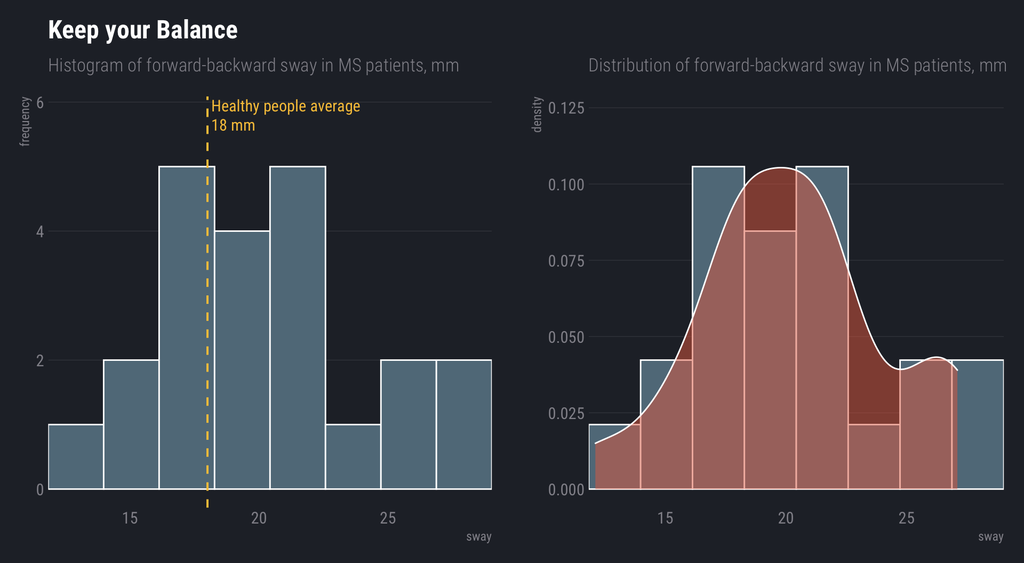

```r
# Frequency Histogram
sway_freq_hist <- ggplot(balance_data, aes(x=sway)) +

  geom_histogram(
    binwidth = 2.15,
    col="white") +

  scale_x_continuous(expand = c(0, 0)) +

  ylim(0,5.8) +

  ## Add "Average 18mm" line
  geom_vline(
    aes(xintercept=18),
    colour="#f7c548",
    linetype="dashed",
    size=0.7) +

  ## Text for vertical line
  annotate(
    geom="text",
    x=18.15,
    y=5.8,
    label="Healthy people average\n18 mm",
    lineheight = 1,
    family=font_rc,
    size=4,
    hjust = "left",
    colour = "#f7c548") +

  ## Title change
  labs(
    title="Keep your Balance",
    subtitle="Histogram of forward-backward sway in MS patients, mm",
    y="frequency") +

  theme_ft_rc(grid="Y") +

  theme(plot.margin=grid::unit(c(5,5,5,5), "mm"))


# Density Histogram
sway_dens_hist <- ggplot(balance_data, aes(x=sway)) +
  geom_histogram(
    aes(y=..density..),
    binwidth=2.15,
    col="white") +

  scale_x_continuous(expand = c(0, 0)) +

  scale_y_continuous(limits = c(0, 5.8/(22*2.15))) +

  geom_density(
    alpha=0.5,
    col="white",
    fill="#e76f51") +

  labs(
    subtitle="Distribution of forward-backward sway in MS patients, mm") +

  theme_ft_rc(grid="Y") +

  theme(plot.margin=grid::unit(c(5,5,5,5), "mm"))

# Calling Plots
set_null_device("png")
plot_grid(sway_freq_hist, sway_dens_hist,
          align="h",
          rel_widths = c(1,1),
          nrow=1,
          ncol=2)
```

### e. Method & P-value

#### i. Method for Hypotheses

We can use the 1 sample t-test.

#### ii. Value of Test Statistic and P-value

The 1 sample **t-test** is defined as $t=\frac{\sqrt n(\bar y-\mu_0)}{s}$  
For this problem,  
$n = 22$  
$\bar y=20.273$  
$s = 3.850$  
$\mu_0 = 18$  
Therefore, $t=2.769$  
From this we can determine that the p-value $=0.01151$

```r
t.test(balance_data$sway, mu=18)
```

```
##
##  One Sample t-test
##
## data:  balance_data$sway
## t = 2.7688, df = 21, p-value = 0.01151
## alternative hypothesis: true mean is not equal to 18
## 95 percent confidence interval:
##  18.56570 21.97975
## sample estimates:
## mean of x
##  20.27273
```

### f. Interpretation of p-value

The p-value gives us information about our sample. It is the probability that we would see a value of $t=2.769$ this extreme or more extreme if the null hypothesis was true. Therefore, if we were to test the sway measurement on another sample of 22 MS patients we will still see an average lower than the healthy people average 1% of the time. However, because that likelihood is so low, we can confidently say that the results we got are not a coincidence.

### h. Assumptions

There are two assumptions in our t-test. First, that the sway measurements are independent from each other. That is, one patients sway does not affect another patient’s sway. Second, we assume that the sway measurements follow a normal distribution. So, the same mean and that the distribution follows a bell-shaped like curve.  
These are reasonable assumptions. First, it is unlikely that the sway of one patient affects the sway of another. Even if watching another patient sway more had an impact on how much the following patient swayed (which is unlikely), these patients are probably not being watched by other patients because of standard research procedures. Second, we can reasonably assume that it approaches a normal distribution. So, the sample mean’s distribution would approach normal distribution for large samples. We can reasonably assume that we have a distribution that approaches normality by looking at the histogram with a distribution line. As we can see, it clearly approaches normality.

## Problem 2

Suspect scale. We take 10 measurements such that $n=10$  
We want to know if the average measurements provided by the scale are different from 12.4 kg, the weight of a standard gold bar.

### a. Confidence Interval

```r
# Mean
writeLines(c("Mean",
             mean(scale_data$mass)))
```

```
## Mean
## 12.4008
```

```r
# Median
writeLines(c("Median",
             median(scale_data$mass)))
```

```
## Median
## 12.3995
```

```r
# Looking for outliers
writeLines(c("Outliers (low & high)",
             find_outlier(scale_data$mass)))
```

```
## Outliers (low & high)
## 12.38025
## 12.41825
```

```r
# Standard deviation
writeLines(c("Standard Deviation",
             sd(scale_data$mass)))
```

```
## Standard Deviation
## 0.00965861733836088
```

```r
# quartile
qt(0.95,9)
```

```
## [1] 1.833113
```

### b. Interpretation of the Confidence Interval

Our 90% confidence interval tells us that if we were to repeat the sampling experiment, we would expect 90% of the repeated calculations to include the correct, true population parameter. That is, the true error between our scale and a perfect scale. However the “true” parameter is unknown.

### c. Hypothesis Test

```r
t.test(scale_data$mass, mu=12.4, conf.level=0.9)
```

```
##
##  One Sample t-test
##
## data:  scale_data$mass
## t = 0.26192, df = 9, p-value = 0.7993
## alternative hypothesis: true mean is not equal to 12.4
## 90 percent confidence interval:
##  12.3952 12.4064
## sample estimates:
## mean of x
##   12.4008
```

$H_0:\mu=12.4$  
$H_A:\mu \neq 12.4$  
The scale is accurate within 0.0008 of 12.4, or 0.0065%  
The p-value is $0.7993$ which is greater than our significance level of $0.1$  
Therefore, we fail to reject the Null Hypothesis, as there is not enough evidence at the $0.1$ significance level.

## Problem 3

Blood pressure (mmHg) measurements.  
Random sample of $n=60$ female diabetics, ages 35-40.  
30 from ethnic group A and 30 from ethnic group B.

### a. Visualizing the Blood Pressure Measurements

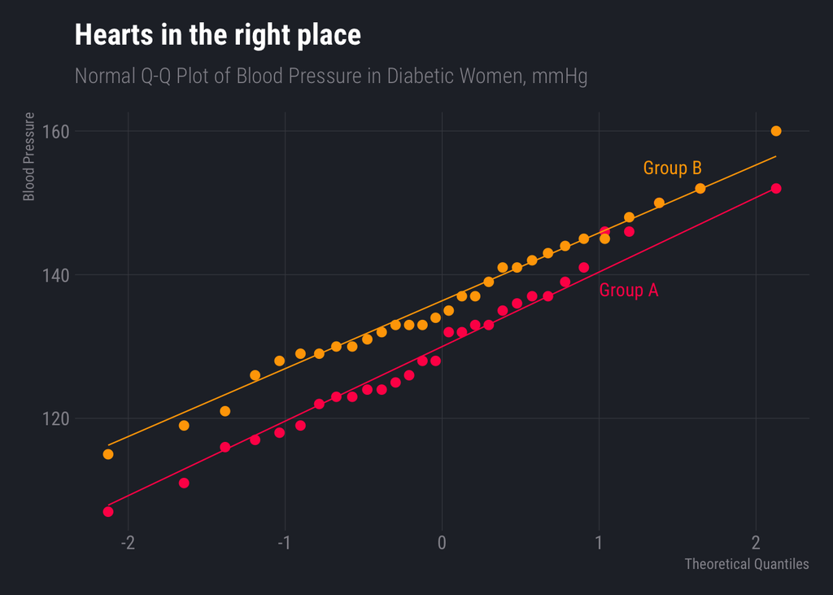

```r
ggplot(bpress_data, aes(sample = bp, colour = group)) +

  stat_qq(size=2.3) +

  stat_qq_line(size=0.4) +

  # Text for Group A
  annotate(
    geom="text",
    x=1,
    y=138,
    label="Group A",
    lineheight = 1,
    family=font_rc,
    size=4,
    hjust = "left",
    colour = ft_cols$red) +

  # Text for Group B
  annotate(
    geom="text",
    x=1.28,
    y=155,
    label="Group B",
    lineheight = 1,
    family=font_rc,
    size=4,
    hjust = "left",
    colour = "#ffa600") +

  theme_ft_rc() +

  theme(legend.position = "none",
        plot.margin=grid::unit(c(5,5,5,5), "mm"),
        panel.grid.minor = element_blank()) +

  scale_colour_manual(values=c(ft_cols$red, "#ffa600")) +

  labs(
    title="Hearts in the right place",
    subtitle="Normal Q-Q Plot of Blood Pressure in Diabetic Women, mmHg",
    x="Theoretical Quantiles",
    y="Blood Pressure")
```

As we can see from the graph, the assumption of normality is reasonable as the values follow their respective reference line quite well. In other words, the data is distributed in such a way that it roughly approaches a straight line, so it can be assumed as normal distribution.

### b. Null & Alternative Hypotheses

$H_0: \mu_A=\mu_B$  
$H_A: \mu_A \neq \mu_B$

```r
# Subsetting data
group_a <- bpress_data[ which(bpress_data$bp
                              & bpress_data$group=="A"), ]

group_b <- bpress_data[ which(bpress_data$bp
                              & bpress_data$group=="B"), ]

# 2 sample t-test
t.test(x=group_a$bp, y=group_b$bp, conf.level = 0.95, df=58)
```

```
##
##  Welch Two Sample t-test
##
## data:  group_a$bp and group_b$bp
## t = -2.0019, df = 56.439, p-value = 0.05011
## alternative hypothesis: true difference in means is not equal to 0
## 95 percent confidence interval:
##  -11.336216649   0.002883316
## sample estimates:
## mean of x mean of y
##  130.4000  136.0667
```

```r
sd(group_a$bp)
```

```
## [1] 11.83973
```

```r
sd(group_b$bp)
```

```
## [1] 10.01011
```

### e. Confidence Interval

```r
qt(0.00188, 58)
```

```
## [1] -3.019505
```

Using the pooled variance and information from part (c) we can be 95% confident that the difference between the means lie between$[0.00049, 11.33291]$

### f. Assumptions

The two assumptions are that the measurements are independent and that they follow a normal distribution. Unless the women in this sample were related, it is unlikely that their blood pressure is affected by the others in the sample. And because it is reasonable to assume that in this sample they are not related to each other, it is reasonable to assume that they are independent.  
As for the normality assumption, if we look at the graph the data points roughly follow straight line. This implies normal distribution. Furthermore, blood pressure is typically normally distributed because extreme values in both tails of the distribution are similarly unlikely.